# R Deep Dive with ggplot2

# 1 - Introduction - About RMarkdown Documents

This is an [R Markdown](http://rmarkdown.rstudio.com) document. When you execute code, the results appear beneath the code. In R Markdown documents, code is embedded in chunks, marked off by three back ticks and then the designation {r}. You can add additional detail about the chunk after the ‘r’, i.e. setup, information about the calculation, etc. You can also specify if you want the code itself to be included in any output documents (the ‘echo’ option), and if you want any displayed results to be included (the ‘eval’ option). By default both options are set to true, so both code and output will be included in any output. We will use code chunks throughout this document for examples, and you will also create your own code chunks.

## How to run a code chunk

To execute a code chunk, click the *Run* button within the chunk (green arrow in the top right), or put your cursor inside the code chunk grey window and press *Cmd+Shift+Enter*.

## Document organization using Markdown

You’ll also notice that sections are marked off by hashmarks - #. This provides formatting when publishing this document as a PDF, slideshow, etc. It also allows for navigation via the navigation bar at the bottom of this document window. You can navigate throughout the document using the menu.

# 2 - Setup

These sets of commands download, install and attach packages we will need for this lesson. If you get a message asking to restart R, click Yes. If you get asked to recompile anything from a source binary, type Yes in the console. Run the code in these code chunks by following the directions given in the *How to run a code chunk* section.

```r
# You can include comments in code chunks by using a hash at the beginning
# of the line.
# This chunk downloads and installs packages into your R installation.
# The options 'eval=F', results="hide", and 'echo=F' tell R to not run or
# display the code or results of this code when creating an output document
# ('knitting').
# Kristin will talk a little more about this on Wednesday and Thursday.

install.packages("tidyverse", repos = "http://cran.us.r-project.org")
install.packages("caTools", repos = "http://cran.us.r-project.org")
install.packages("bitops", repos = "http://cran.us.r-project.org")
install.packages("PeriodicTable", repos = "http://cran.us.r-project.org")
install.packages("ggplot2", repos = "http://cran.us.r-project.org")
```

```r
# This chunk loads the packages into your current R environment.
# This needs to be done whenever you are creating ('knitting') an output
# document from this file.

library("tidyverse")
library("caTools")
```

```r
library("bitops")
library("PeriodicTable")
library("ggplot2")
```

We will be working with a dataset from the **PeriodicTable: Periodic Table of the Elements package by Julien Idé**. Information and documentation about this dataset can be found here: https://cran.r-project.org/package=PeriodicTable.

Run the code chunk below to load this dataset into the R environment.

```r
data(periodicTable)
```

You should now see `periodicTable` in the Environment tab on the right side of your RStudio window.

Let’s take a look at what’s in here. Run the following code chunk to see some characteristics of our data frame.

```r
str(periodicTable)
```

```
## 'data.frame':    117 obs. of  28 variables:
##  $ numb      : int  0 1 2 3 4 5 6 7 8 9 ...
##  $ symb      : chr  "Xx" "H" "He" "Li" ...
##  $ name      : chr  "Dummy" "Hydrogen" "Helium" "Lithium" ...
##  $ mass      : num  0 1.01 4 6.94 9.01 ...
##  $ rcov      : num  0.1 0.31 0.28 1.28 0.96 0.84 0.76 0.71 0.66 0.57 ...
##  $ rvdw      : num  0 1.1 1.4 1.81 1.53 1.92 1.7 1.55 1.52 1.47 ...
##  $ rion      : num  0 0.012 NA 0.76 0.35 0.23 NA 0.13 1.4 1.3 ...
##  $ color     : chr  "#1280B3" "#FFFFFF" "#D9FFFF" "#CC80FF" ...
##  $ red       : num  0.07 1 0.85 0.8 0.76 1 0.5 0.05 1 0.7 ...
##  $ green     : num  0.5 1 1 0.5 1 0.71 0.5 0.05 0.05 1 ...
##  $ blue      : num  0.7 1 1 1 0 0.71 0.5 1 0.05 1 ...
##  $ period    : int  NA 1 1 2 2 2 2 2 2 2 ...
##  $ group     : int  NA 1 18 1 2 13 14 15 16 17 ...
##  $ type      : chr  NA "Nonmetal" "Noble Gas" "Alkali Metal" ...
##  $ phase     : chr  NA "gas" "gas" "solid" ...
##  $ crystal   : chr  NA "" "" "bcc" ...
##  $ Eneg      : num  NA 2.2 NA 0.98 1.57 2.04 2.55 3.04 3.44 3.98 ...
##  $ IP        : num  NA 13.6 24.59 5.39 9.32 ...
##  $ density   : num  NA 8.99e-05 1.78e-04 5.34e-01 1.85 ...
##  $ melting   : num  NA 14.2 NA 453.9 1560.2 ...
##  $ boiling   : num  NA 20.28 4.22 1615 2742 ...
##  $ isotopes  : int  NA 3 5 5 6 6 7 8 8 6 ...
##  $ discoverer: chr  NA "Cavendish" "Janssen" "Arfvedson" ...
##  $ year      : int  NA 1766 1868 1817 1798 1808 NA 1772 1774 1886 ...
##  $ C         : num  NA 14.3 5.19 3.58 1.82 ...
##  $ config    : chr  NA "1s1" "1s2" "[He] 2s1" ...
##  $ row       : int  NA 1 1 2 2 2 2 2 2 2 ...
##  $ col       : int  NA 1 18 1 2 13 14 15 16 17 ...
```

In the Environment tab, clicking on the arrow in the blue circle will display the same basic information (the “`str`ucture”) about this data frame. If we want to look at all the data in a table format, click on the **name** of the data frame in the Environment tab. This will open up a new object tab in the upper left, next to this window.

# 3 - Simple Scatter Plot

There’s lots of data that we can play with here. Let’s start by making a simple plot of atomic mass versus atomic number to check the integrity of our data. What should this plot look like? Run the code below to generate a graph.

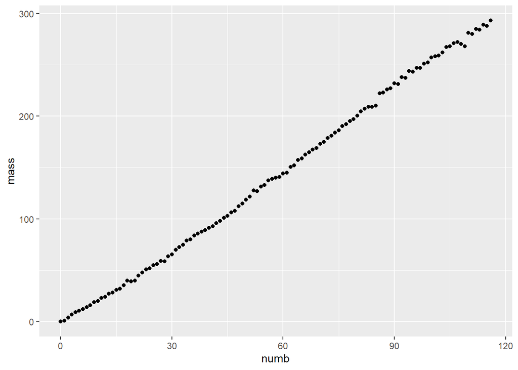

```r
ggplot(data=periodicTable, aes(x=numb,y=mass)) + geom_point()
```

This is an example of the most basic of ggplots. It has three key elements:

1. `data=`: the data you are plotting (usually the name of your data frame in your environment)
2. `aes()`: these are the **`aes`thetic** mappings for the plot - how we are visually representing the data variables. The basic ones used here are:
- what data to plot on the x axis (`x=vector_in_dataframe`)
- what data to plot on the y axis (`y=vector_in_dataframe`)
3. An additional **layer**, signified by the `+` symbol, called `geom` to describe what the plotted data should look like (in this case, what symbol should be used for the scatterplot).

In this case, we are using the **periodicTable** dataframe, and plotting **numb** on x and **mass** on y. We are specifying the data be represented as individual points (`geom_point`).

## Exercise 3.1 - Finding A Pattern

Add a new chunk below by clicking the *Insert Chunk* button (top of the window on the toolbar) or by pressing *Cmd+Option+I*. Make a scatter plot of density (y axis) versus [atomic] mass (x axis). Plot the data as points.

## Exercise 3.2 - `geom_point` Options

There are many options and aesthetics that you can add to a simple scatter plot using geom_point. An extensive overview can be found in the [online ggplot2 reference](https://ggplot2.tidyverse.org/reference/geom_point.html).

Let’s re-plot our density graph with the following three additions to the `geom_point` layer, between the parentheses:

1. Change the color to red: `color = "red"`
2. Change the shape to triangles: `shape = "triangle"`
3. Remove the missing values: `na.rm = TRUE`

Add a new chunk below by clicking the *Insert Chunk* button (top of the window on the toolbar) or by pressing *Cmd+Option+I*. Re-plot your expression from Exercise 3.1 and add the above options to the `geom_point() layer`, separating each option by a comma.

## Exercise 3.3 - Using Color to Elucidate Patterns

We can see from the previous plots some of the periodicity behind the periodic table :) We’ve seen that we can change the color of an entire plot. Can we use color to further pick out the changes from the table by coloring the points according to what period they are in? We can do this by specifying an additional aesthetic in the main data layer using `aes()`.

## Exercise 3.4 - Adding Color by Factor

Our previous plot shows us the variation, but it would be more accurate to have the periods as discrete colors and not a gradient. The reason it plotted period as a gradient is because in the data frame, period is an *integer*. ggplot treats number and integer vectors as continuous variables by default - hence it uses a gradient color scheme. In this case, we want period to be a categorical value, or a factor. This can be done by changing `color=period` to `color=factor(period)`.

# 4 - Adding a Fit

Let’s go back to our original graph of **mass** versus **numb** from the beginning of Section 3 (Chunk 4, the section_3_mass_vs_numb chunk, if you are using the navigation menu at the bottom):

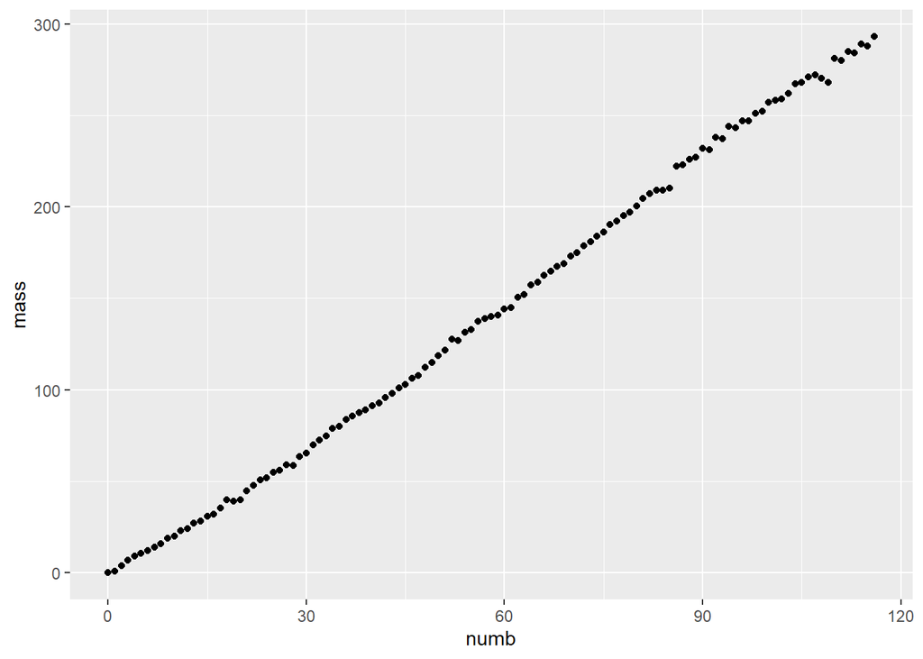

```r
ggplot(data=periodicTable,aes(x=numb,y=mass)) + geom_point()
```

We would like to add a linear fit to this graph. We can do this by adding a layer of `geom_smooth()` and specifying the model we want to use. There are many options that can be used for a fit - more info on `geom_smooth()` can be found here: https://ggplot2.tidyverse.org/reference/geom_smooth.html.

## Exercise 4.2 - Adding linear fit parameters to the plot

It might be useful to display the parameters, like slope and intercept, of the fitted line on the graph. How can we do that? Although the plot is calculated by ggplot, we need to do the calculation for the fit parameters outside of ggplot in order to get the exact numbers. Then we can add them to the plot.

The following code runs a simple linear model approximation on our data (“lm”), stores it in an object called ‘mass_correlation’, and displays the slope and intercept values of the line we generated above. “lm” is a function contained in the “stats” package, which is included in the standard installation of R.

Run the code below. Do the numbers make sense?

```r
mass_correlation <- lm(mass ~ numb, data=periodicTable)
coef(summary(mass_correlation))
```

```
##              Estimate  Std. Error   t value      Pr(>|t|)
## (Intercept) -9.004058 0.666401668 -13.51146  1.714181e-25
## numb         2.613775 0.009928983 263.24703 9.504291e-162
```

We can pull out the specific correlation values using the following indices - run the code below to assign these values to objects called intercept and slope:

```r
intercept <- mass_correlation$coefficients[1]
slope <- mass_correlation$coefficients[2]
intercept
```

```
## (Intercept)
##   -9.004058
```

```r
slope
```

```
##     numb
## 2.613775
```

Since we are focusing on plotting here and not on statistics, let’s figure out how to get this on our plot. Believe it or not this is not as straightforward as one might think. Text is added to plots using an `annotate()` layer. More info on `annotate()` can be found here: https://ggplot2.tidyverse.org/reference/annotate.html.

The options for `annotate()` include the type of annotation (in this case “text”), the position on the graph (x and y values), and the value (this can be a reference to a value in a vector, dataframe or list, indicated by `label=`).

Run the code below to show how to add a text annotation for the intercept value to the plot:

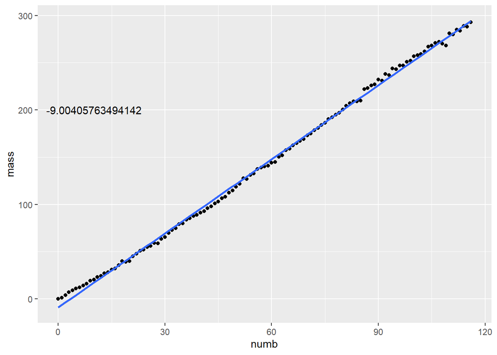

```r
ggplot(data=periodicTable,aes(x=numb,y=mass)) + geom_point() + geom_smooth(method="lm") + annotate("text", x=10, y=200, label=intercept)
```

Let’s add the slope value to the graph now. Add a new chunk by clicking the *Insert Chunk* button (top of the window on the toolbar) or by pressing *Cmd+Option+I*. Copy the code from the `section_4_2-add_annotation chunk` above and add a second `annotate()` layer to add the value for the slope. You may need to adjust your x and y values!

## Exercise 4.3 - Customizing annotations

It would be nice to describe what those values are on the plot. There are ways to add more text (i.e. label the values for the slope and intercept). You can combine text and calculated values using the `paste()` command in your label, i.e. `paste("Intercept = ", intercept)` and using this in the label option. Run the following code for an example:

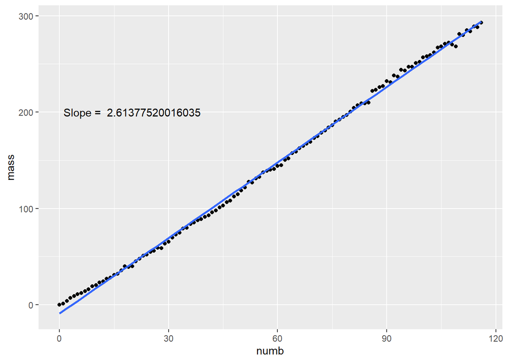

```r
ggplot(data=periodicTable,aes(x=numb,y=mass)) + geom_point() + geom_smooth(method="lm") + annotate("text", x=20, y=200, label=paste("Slope = ", slope))
```

Let’s add the equation for the line to the graph. Add a new chunk by clicking the *Insert Chunk* button (top of the window on the toolbar) or by pressing *Cmd+Option+I*. Copy the code from the `section_4_3-label_using_paste` chunk above and change the annotate layer so the equation y = slope*x + intercept shows up on the graph.

# 5 - Bar Charts

We have a number of different variables we can look at. Let’s make a bar chart to count how many elements there are of each type.

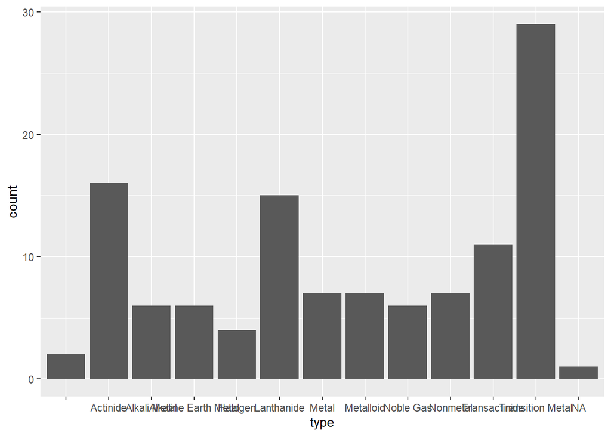

```r
ggplot(data=periodicTable) + geom_bar(mapping=aes(x=type))
```

You can pop out the graph into a separate window to de-smush the x-axis by clicking the small square icon (next to the arrows) in the top right of the graph window.

## Exercise 5.1 - Customizing Axes Text

Let’s add some axes titles and a chart title to our element type plot. We can add a layer of labels using the following: `+ labs(x = "X Axis Label", y = "Y Axis Label", title = "Plot Title")`

## Exercise 5.2 - Customizing Axes Position

What would make this plot look a little better?

We can rotate the X-axis label text using a `theme()` layer. This layer is where all the non-content (i.e. non-data) elements of ggplot graphs live. There are tons of options for themes (use help -> theme), and also many pre-defined themes.

Let’s re-plot our graph and make it a little easier to read. Add a new chunk by clicking the *Insert Chunk* button (top of the window on the toolbar) or by pressing *Cmd+Option+I*. To make our text a little easier to read, add the following layer to the graph: `+ theme(axis.text.x=element_text(angle=90,hjust=1,vjust=0.5))`

The `element_text` command will change the `angle`, `hjust` (horizontal justification/position) and `vjust` (vertical justification/position) for the text of the X axis element (`axis.text.x`).

## Exercise 5.3 - Assigning a Plot to an Object for Reuse

Let’s say you want to experiment with a few different label types, but do not want to have to re-type the entire ggplot command every time you make your graph. At any point, with any number of layers, a ggplot can be assigned to an object, and that object can then be called and modified with further layers.

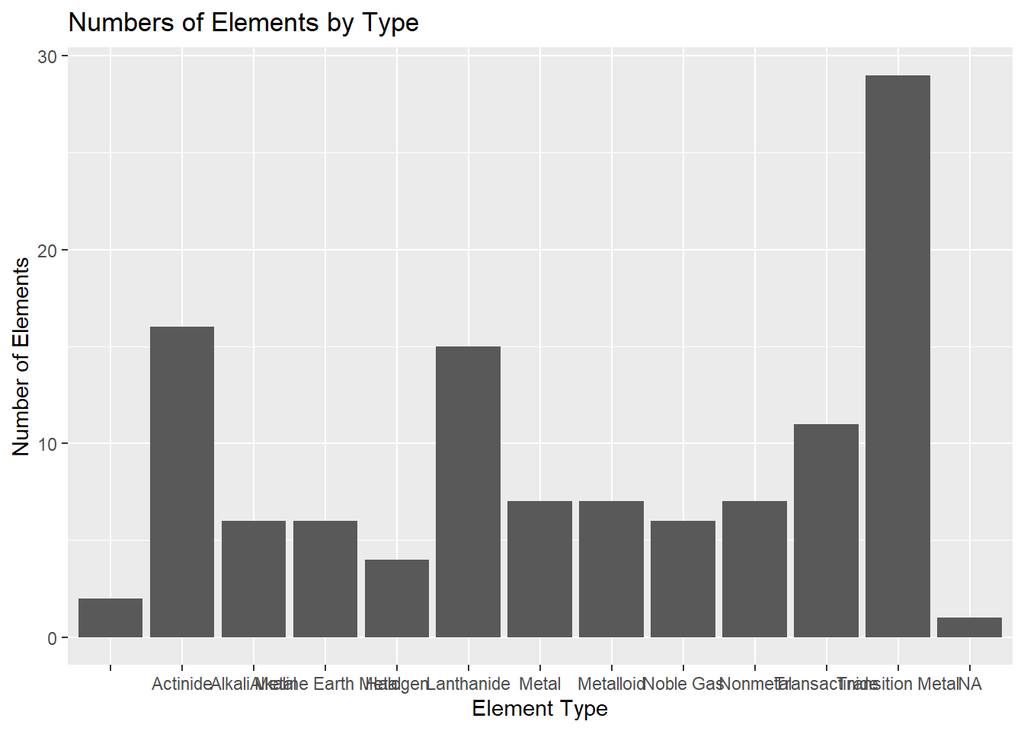

```r
et <- ggplot(data=periodicTable) + geom_bar(mapping=aes(x=type)) + labs(x="Element Type", y="Number of Elements", title="Numbers of Elements by Type")
et
```

You can see now that a new object, **et**, is available in the Global Environment, and you can inspectthe additional plotting parameters that are stored in there. Why is this important? You may have a situation where you will be working with the same basic plot type over and over again - this gives you a programmatic way to modify aspects of the graph without retyping (or copy/pasting) the entire command. In general, for reproducible analysis, using objects is highly recommended.

Now, if we want to add a theme layer to our base et plot, we can simply run: `et + theme()`

Challenge: see if you can get the text to line up just below the X axis! What element of `element_text` do you need to change?

## Exercise 5.4 - How Many Phases?

# 6 - Three-Dimensional Plots: Periodic Table Trends

We know that there are trends that we can see in the periodic table. This is an example of three-dimensional data. We have the two dimensions of the periodic table - row and column - and our third dimension is the property that varies with them. Examples of this variance can be seen in ionic radius, electronegativity, etc.

Let’s make a plot of the periodic table that will show some of these trends. Run the code below to create a plot of the periodic table showing variance of electronegativiy with table position. The main layer creates the table, with X being the column and Y being the row. One type of 3D plot is `geom_tile`, and the aesthetic that we tell it to fill with is the Eneg (electronegativity) value (the “z” direction). So we should expect to see a color variance (pop quiz: what type of vector is Eneg?) with position in X and Y.

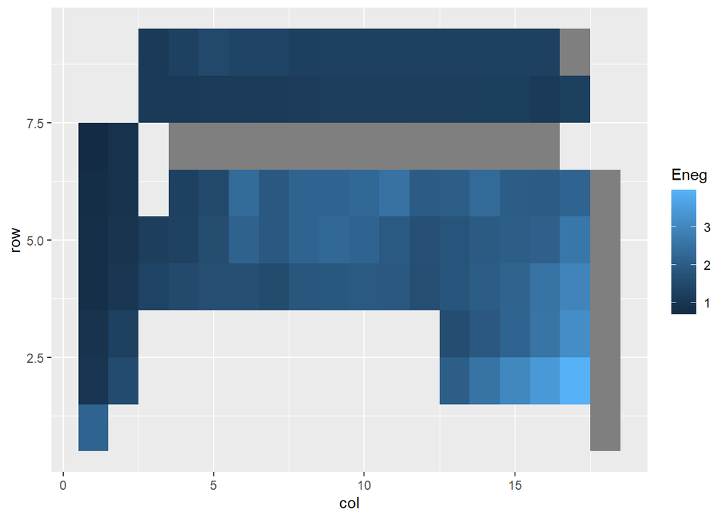

```r
ggplot(data=periodicTable,aes(x=col,y=row)) + geom_tile(aes(fill=Eneg))
```

## Exercise 6.1 - Manipulating Axes

So this looks close - what do we need to do to fix this?

Let’s start by flipping the Y-axis. Add a new chunk by clicking the *Insert Chunk* button (top of the window on the toolbar) or by pressing *Cmd+Option+I*. Add the following line: `+ scale_y_reverse()`

Looks better!

## Exercise 6.2 - Customizing Ticks and Labels 1

We could see things a little better if we had a better scale on the X and Y. Add a new chunk by clicking the *Insert Chunk* button (top of the window on the toolbar) or by pressing *Cmd+Option+I*. Copy your code from the previous exercise and add the following line to modify the X axis: `+ scale_x_continuous(breaks=seq(1,18,1))`

## Exercise 6.3 - Customizing Ticks and Labels 2

How can we do the same thing for the Y axis? Add a new chunk by clicking the *Insert Chunk* button (top of the window on the toolbar) or by pressing *Cmd+Option+I*. What option can we add to `scale_y_reverse()` to get the row numbers listed individually?

Note that ggplot automatically removes missing data!

## Exercise 6.4 - Adding Axis Titles and Labels

The `scale_fill_continuous() layer` is how you customize the legend and color for continuous data - in this case, our electronegativity values. There are different options if you have manually assigned or discrete data - see http://www.cookbook-r.com/Graphs/Legends_(ggplot2)/ for more info on how to customize legend colors and text.

## Exercise 6.5 - Exporting a plot

Let’s make one more plot based on the periodic table. Copy your plot from Exercise 6.4, and choose another continuous numeric variable to plot. Some choices are:

- mass - Atomic masses
- rcov - Covalent radii
- rvdw - Van der Waals radii
- rion - Ionic radii
- IP - First ionization potential
- density
- melting - Melting points
- boiling - Boiling points
- C - Heat capacities

Customize the axes and title accordingly.

Once you are happy with your plot, you can save it using the `ggsave()` command. There are other ways that offer more options, but this is one of the simplest and most common. It defaults to saving the last plot that was created. Run the following code to save your last plot to a jpeg file in your working directory:

```r
ggsave("periodic_table_plot.jpeg")
```

By default ggsave identifies the file type (or “device”) based on the filename extension. You can specify a number of different file types by specifying the file type extension in your filename - i.e. periodic_table_plot.tiff, periodic_table_plot.pdf, etc. You can also specify width, height, and units of measure. More detail can be found on the https://ggplot2.tidyverse.org/reference/ggsave.html.

# Acknowledgements

Gail Clement, Head of Research Services, California Institute of Technology, for inspiration and assistance with proofreading and teaching.

Parts of this lesson are inspired by *Data Science in the tidyverse* by Charlotte Wickham, which is licensed under a Creative Commons Attribution 4.0 International License and based on a work at https://github.com/rstudio/master-the-tidyverse.

# References

1. More information can always be found in the package help!
2. https://ggplot2.tidyverse.org/reference/
3. ggplot2: Elegant Graphics for Data Analysis, 3nd Ed. (in progress), by Hadley Wickham: https://ggplot2-book.org/
4. R for Data Science by Hadley Wickham, http://r4ds.had.co.nz/data-visualisation.html
5. https://groups.google.com/forum/#!forum/ggplot2
6. ggplot2 cheatsheet (2021-08): https://raw.githubusercontent.com/rstudio/cheatsheets/main/data-visualization.pdf
7. https://www.computerworld.com/article/2935394/business-intelligence/my-ggplot2-cheat-sheet-search-by-task.html